# BioStats m200 Homework 3

Andrew Howe

April 25, 2015

# Part I

## Further Reading

1. Failure to clearly report sample size in text
2. Failure to provide 95% confidence interval for a correlation coefficient
3. Inappropriate regression line in plot when only correlation is calculated
4. Failure to address or exclude outliers in plots and calculations
5. Inappropriate use of a correlation coefficient when either of the following is true :
- sample size is small
- data plot suggests a non-linear association
6. Inappropriate use of Pearson (linear) correlation coefficient when Spearman (monotonic nonlinear) correlation coefficient is appropriate
7. Failure to identify and address heteroscedasticity (variation in variance)
8. Inappropriate satisfaction with an outcome based solely on significance value
9. Failure to report sample size in figure
10. Confusion of correlation with regression
11. Failure to provide anything but a correlation coefficient on data plot
12. Failure to state the type of regression line plotted
13. Failure to depict 95% confidence interval around an appropriate regression line
14. Failure to provide hyperbolic 95% confidence intervals for the regression line
15. Inappropriate comparison of regression slope instead of analysis of covariance statistic

On the whole, these errors render results difficult to interpret at best, and downright misleading at worst.

# Part II

## Data Analysis

### Vascular Endothelial Growth Factor (VEGF)

#### 1.1 VEGF Levels at Each Timepoint

Summary Statistics for VEGF Timepoints :

```
##               1       2
## Min.      70.51   23.21
## 1st Qu.  122.80  121.20
## Median   404.00  234.50
## Mean     515.50  352.30
## 3rd Qu.  707.00  460.00
## Max.    1845.00 1328.00
```

```
## [1] "MADAM"
```

```
##     1     2
## 284.5 129.0
```

Visualization of VEGF data at two different timepoints.

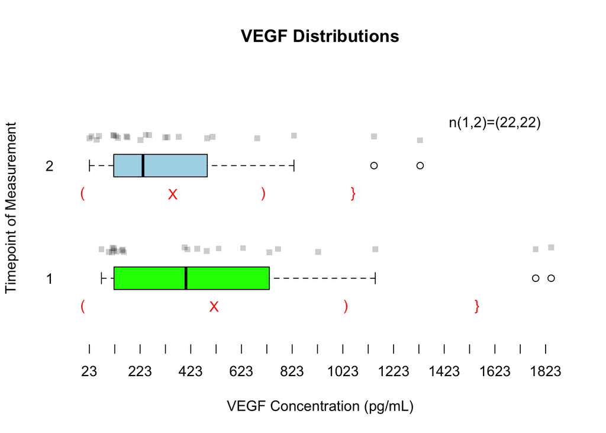

#### 1.2 QQ Plots of VEGF Data

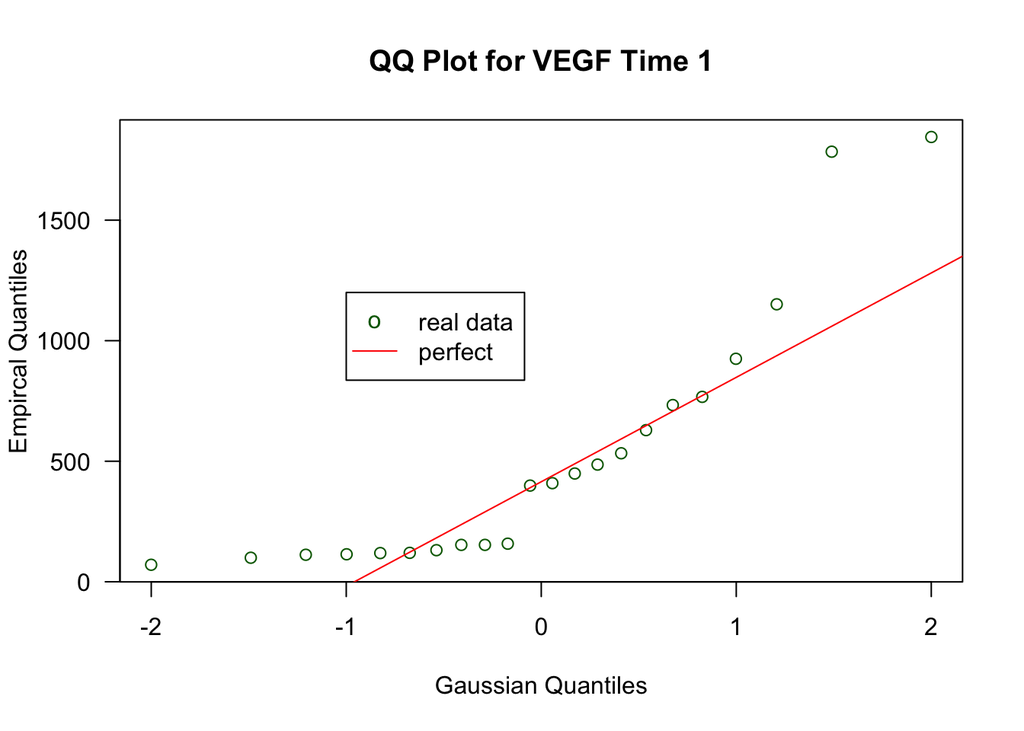

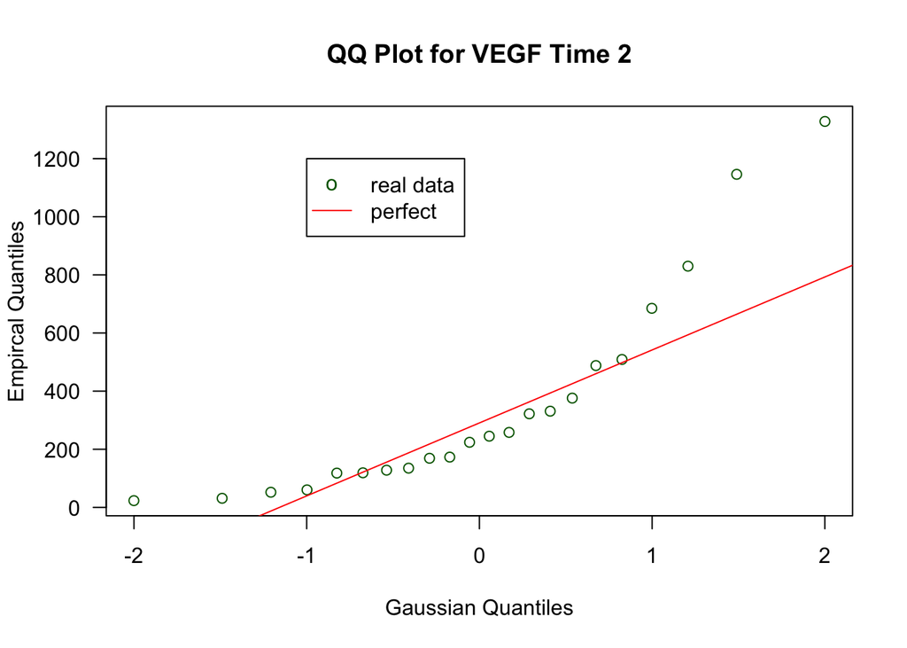

#### 1.3 Summary and Appropriate Descriptors

At both timepoints, VEGF data is skewed, with data concentrated to the left of the median and spread to the right of the median, giving the data a fat right tail. Each time point only has 22 measurements associated with it, rendering histograms less helpful. Instead, a stripchart is displayed alongside a boxplot and Gaussian summary statistics (red symbols where the mean is the X and one and two standard deviations away from the mean are depicted with parenthesis and curly braces, respectively).

Both data sets contain outliers in the high end of VEGF concentration. In both cases, the outliers pull the means of the data away from the median.

At timepoint one, there is a relatively tight group of data concentrated in the 25th percentile.

Combined with the observations in the QQ plot, it is fairly clear that this data cannot be appropriately described with Gaussian summary statistics. Central tendency is best described by the median.

**Median**

```
## [1] "timepoint"
```

```
##     1     2
## 404.0 234.5
```

**MAD**

```
## [1] "timepoint"
```

```
##     1     2
## 284.5 129.0
```

#### 2. Bootstrapping

**Median Bootstraping**

*This list apply function does not seem to want to provide anything but the first title. It should be titled T1 and then T2.

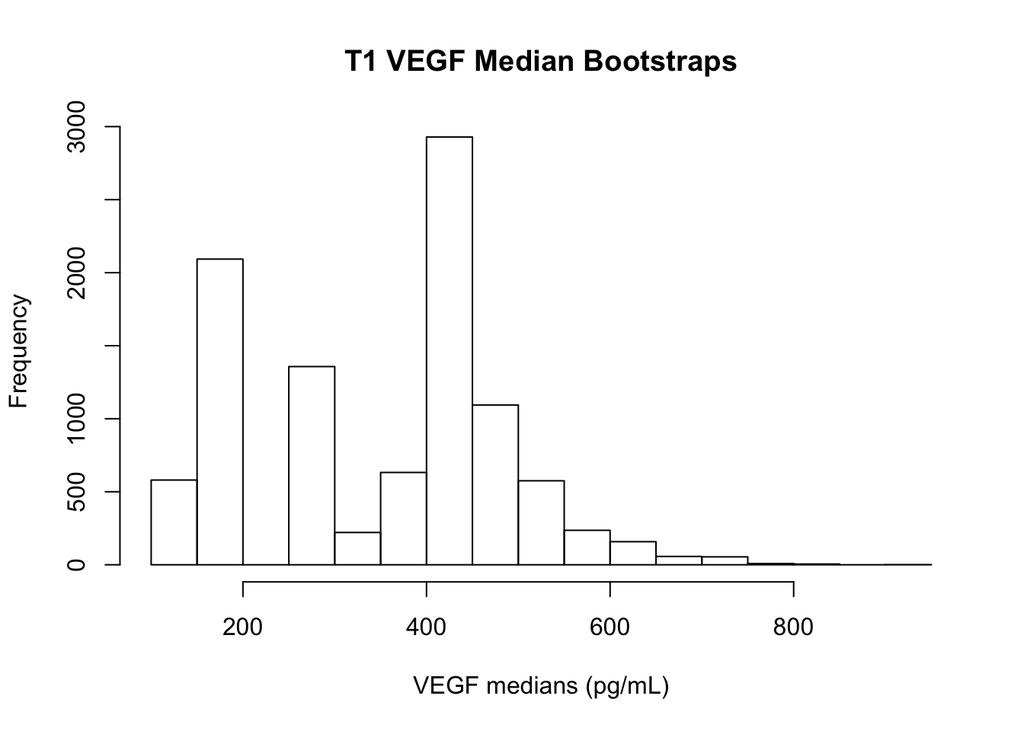

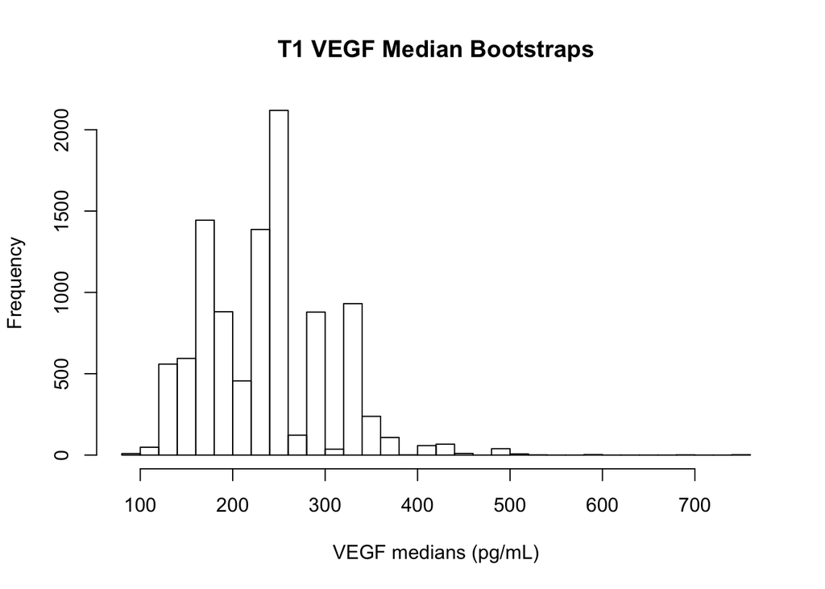

**MAD Bootstrapping**

*This list apply function does not seem to want to provide anything but the first title. It should be titled T1 and then T2.

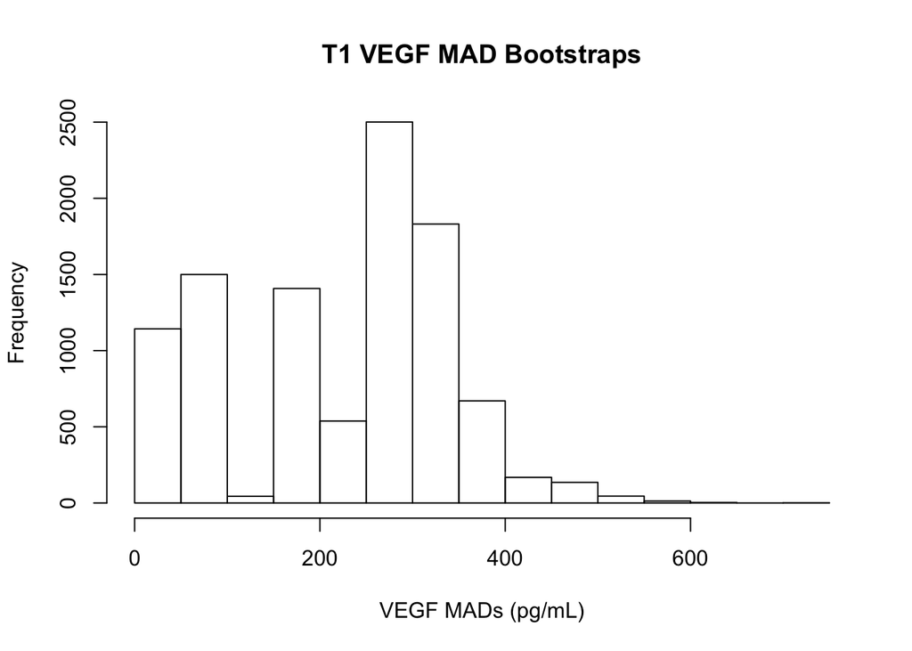

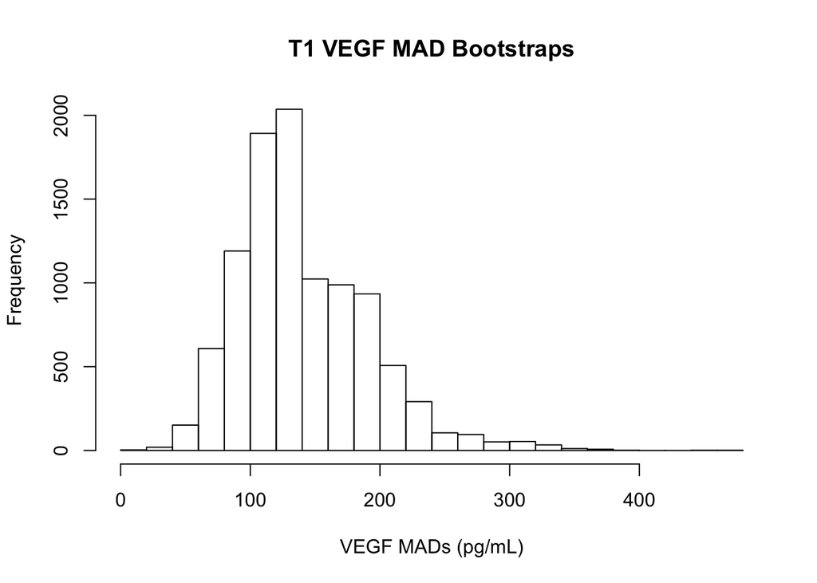

#### Bootstrapped Summary Statistics

**Median Bootstrap Summary Stats**

```
##             1      2
## Min.    116.5  89.15
## 1st Qu. 158.0 173.00
## Median  404.0 234.50
## Mean    348.9 234.70
## 3rd Qu. 449.0 273.00
## Max.    942.0 757.50
```

**MAD Bootstrap Summary Stats**

```
##              1     2
## Min.      7.50  10.0
## 1st Qu.  84.99 105.0
## Median  262.00 130.0
## Mean    222.10 140.7
## 3rd Qu. 306.50 171.0
## Max.    726.00 461.0
```

#### 95% Confidence Intervals on Medians

**Lower 95% CI :**

```
## [1] "timepoint"
```

```
##   1   2
## 136 128
```

**Median :**

```
##     1     2
## 404.0 234.5
```

**Upper 95% CI**

```
##   1   2
## 629 376
```

#### 95% Confidence Intervals on MADs

**Lower 95% CI :**

```
## [1] "timepoint"
```

```
##      1      2
## 31.338 63.500
```

**Madam :**

[output not shown]

**Upper 95% CI :**

```
##     1     2
## 425.5 261.0
```

#### 3. Bootstrapped Effect Size with Confidence Intervals

**Effect Size**

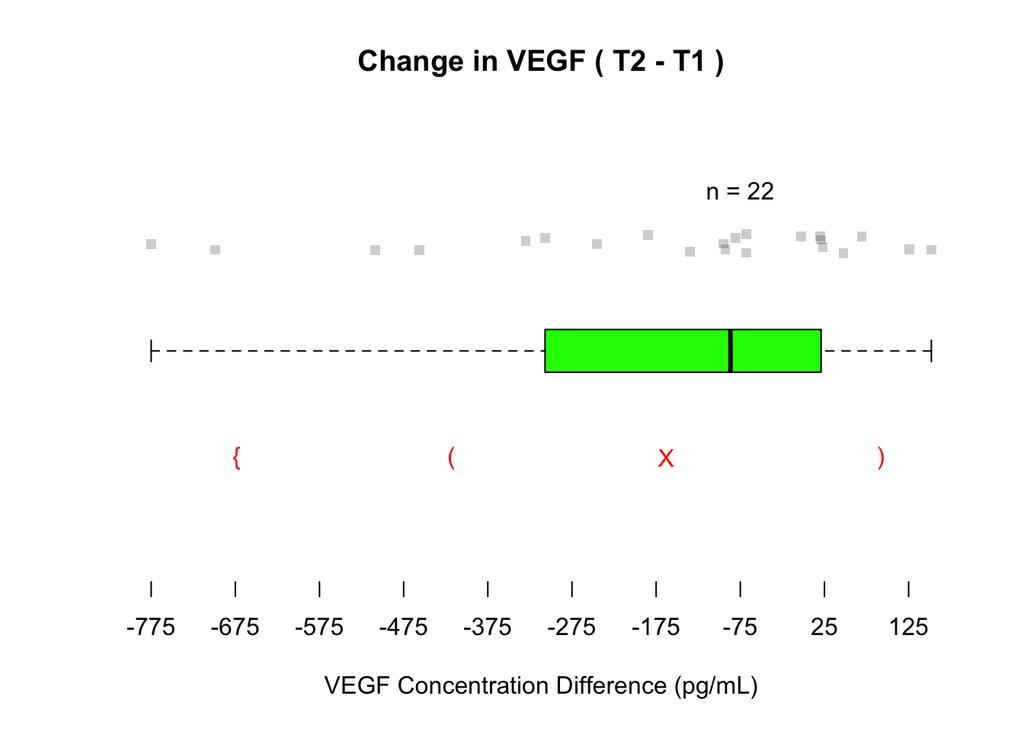

**Assuming the populations are different :**

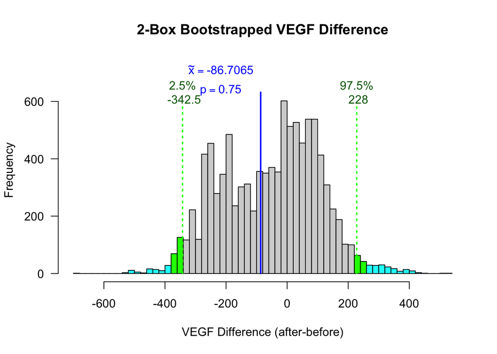

**Assuming the populations are the same :**

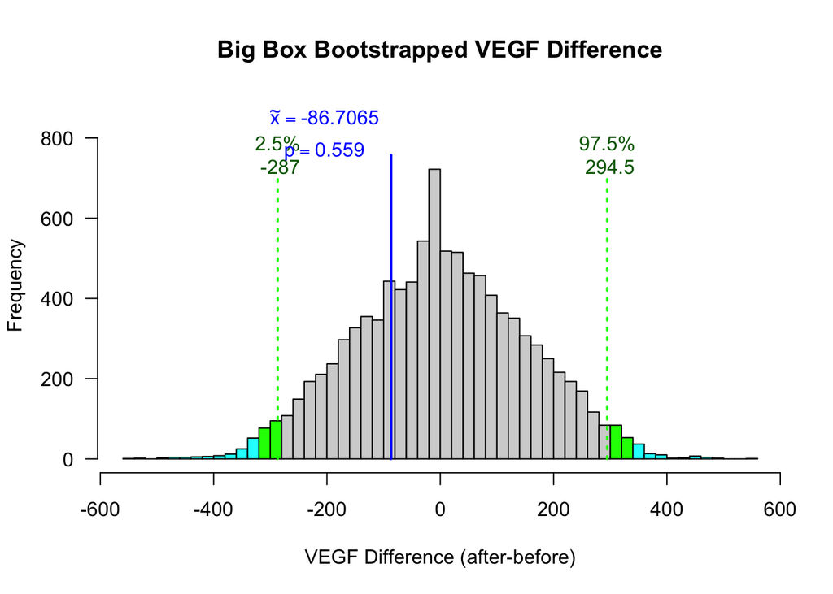

The difference before and after surgery is not significant.

### Statistical Independence

Are these cytokine levels related?

#### 1. Cytokine Pair Scatterplot

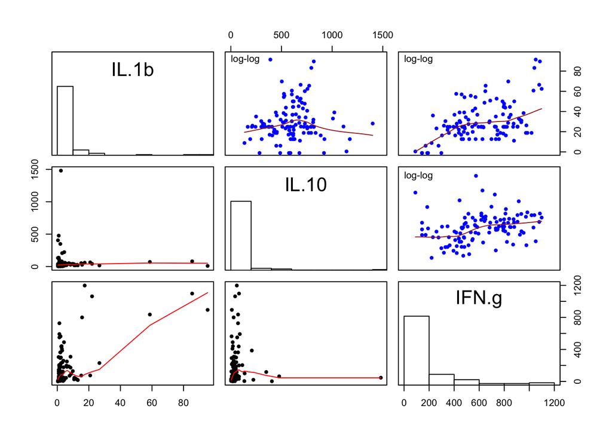

Histograms of the data are plotted along the identity line of the matrix. Upper panels contain log-log plots (blue points) with Loess smoothed x-y lines (red) plotted through the points. Lower panels contain raw data plots with smoothed x-y lines (red). Each plot contains 119, 3 columns by all possible pairs of the second dimension.

None of these plots are characteristically Gaussian bivariate distributions.

Each linear (lower panels) plot contains at least one clear outlier.

These plots reveal that IL.1b vs IFN.g is heteroskedastic (in the y axis in the lower panel).

##### An Appropriate Measure of Association

Given the assumptions of Gaussian characteristics for Pearson correlation and linear regression, neither approach is appropriate with these data sets. Instead, I will use Spearman correlation.

#### 2. Estimation of Association

**Spearman Correlation** of :

*cytodata$IL.1b X cytodata$IL.10*

```
## [1] 0.1217036
```

*cytodata$IL.1b X cytodata$IFN.g*

```
## [1] 0.4205736
```

[output not shown]

##### Bootstraps on Estimation

*Confidence Intervals for Spearman Correlation*

Here, we repeatedly test the correlation coefficient with resampling of the available data to estimate the range of the correlation statistic.

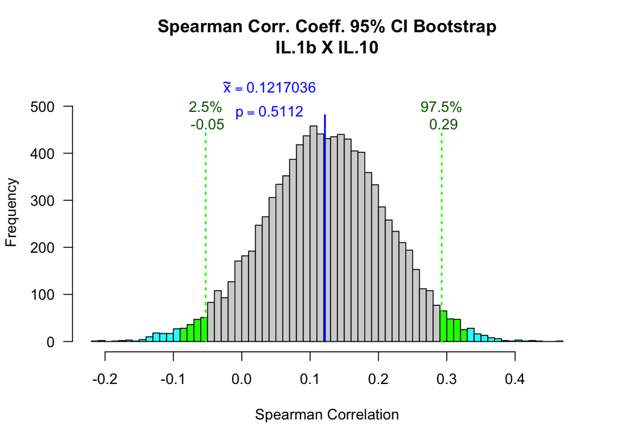

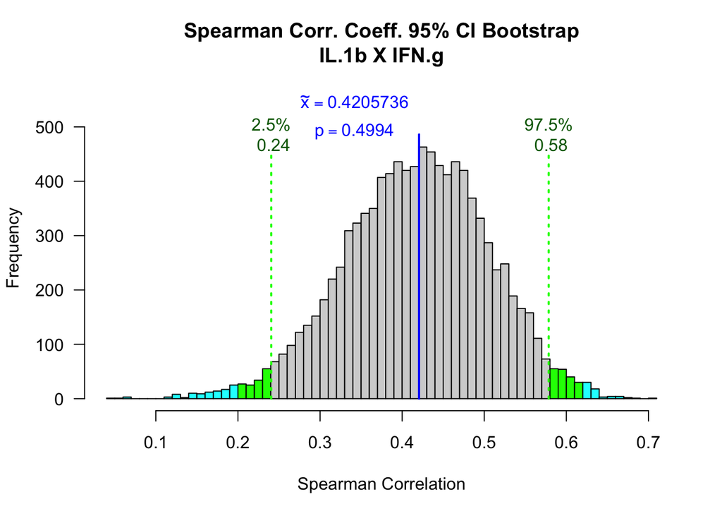

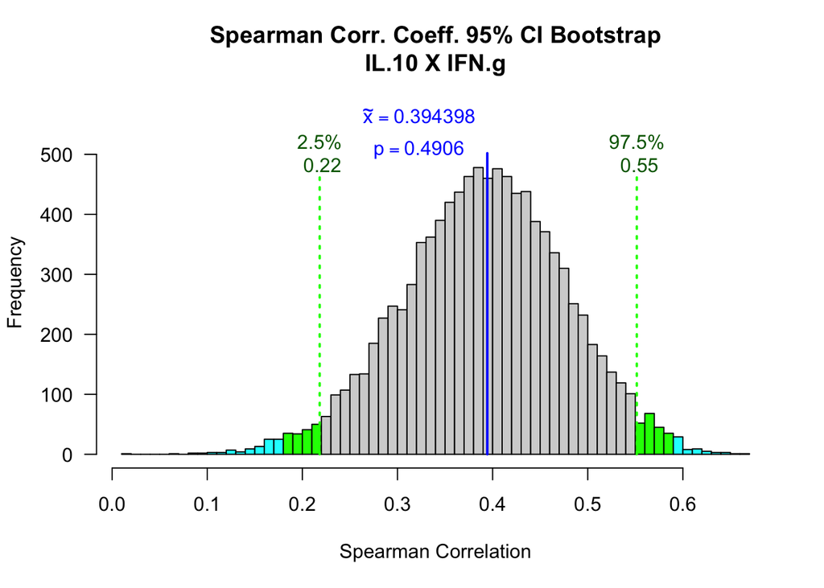

#### 3. Null Hypothesis Significance Test (NHST) for Spearman

*NHST for Spearman Correlation*

Here, we test significance by repeatedly breaking the pairings of the data points; if there is a correlation present in the data, breaking the pairings should reduce the correlation. Then, we compare the observed correlation value to the population of broken-pair correlations to estimate whether a correlation exists.

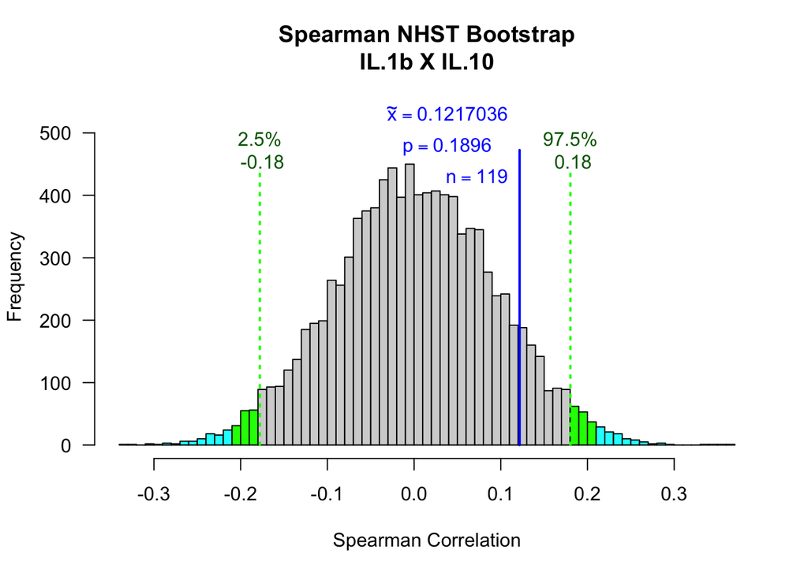

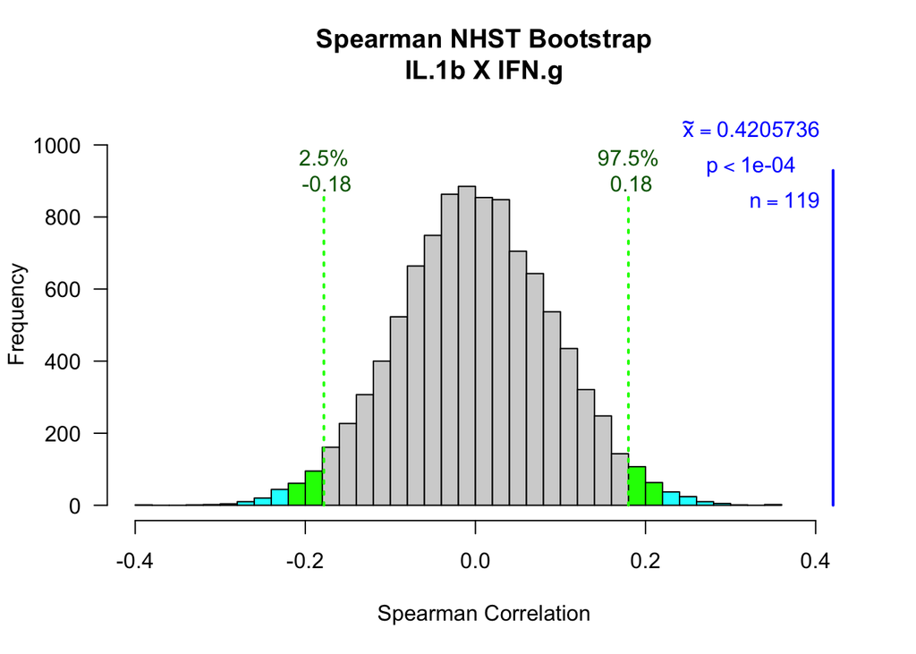

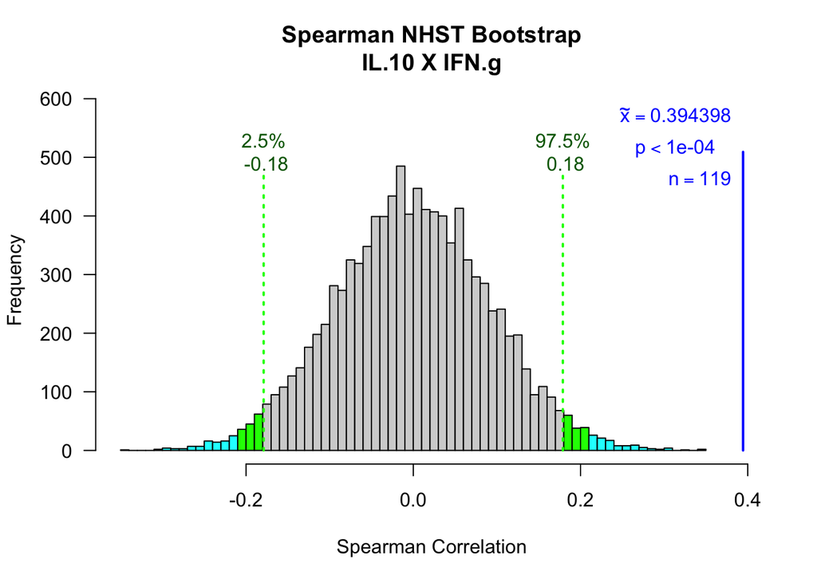

#### 4. *Follow All the Porter Rules*

1. Failure to clearly report sample size in text
- *see above*
2. Failure to provide 95% confidence interval for a correlation coefficient
- *see plot*
3. Inappropriate regression line in plot when only correlation is calculated
- *no regression provided because only correlation calculated*
4. Failure to address or exclude outliers in plots and calculations
- *outliers commented upon in text*
- *calculations are rank based (Spearman) mitigating outlier effects*
5. Inappropriate use of a correlation coefficient when either of the following is true :
- sample size is small – *sample size should be addequate*
- data plot suggests a non-linear association – *rank based correlation should help mitigate the effect of non-linearity; some non-linear association is suggested by the vaguely linear associations in the log-log pair plot (upper panels)*
6. Inappropriate use of Pearson (linear) correlation coefficient when Spearman (monotonic nonlinear) correlation coefficient is appropriate
- *used Spearman instead of Pearson because the assumptions of Pearson were not fulfilled (see above)*
7. Failure to identify and address heteroscedasticity (variation in variance)
- *Heteroscedasticity commented upon above; rank based correlation should help mitigate this effect*
8. Inappropriate satisfaction with an outcome based solely on significance value
- *n/a*
9. Failure to report sample size in figure
- *see figures*
10. Confusion of correlation with regression
- *n/a*
11. Failure to provide anything but a correlation coefficient on data plot
- *n/a*
12. Failure to state the type of regression line plotted
- *see text above; lines provided on scatter plots are smoothed Loess trend lines, not regression*
13. Failure to depict 95% confidence interval around an appropriate regression line
- *no regression drawn; 95% CI provided for correlation*
14. Failure to provide hyperbolic 95% confidence intervals for the regression line
- *n/a*
15. Inappropriate comparison of regression slope instead of analysis of covariance statistic
- *n/a*

#### 5. Commentary on the Correlations

##### IL.1b X IL.10

The two IL.1x factors do not appear to have a useful correlation. The 95% CI for the correlation spans zero, and the correlation is overall low. The NHST for this pairing failed to reach significance in the NHST bootstrap. Examining the raw correlations further, the linear axes plot almost seems to have two orthagonal trends in it, supporting the conclusion that these are likely unrelated factors. The log-log plot brings the outliers close to the body of the data, and spreads the lower points in a way that allows better visualization. In the log-log plot, the orthagonal components remain, although they are much less obvious. The data is not completely decorrelated, as the data does not occupy all the available space in either scale of the scatter plot, but there is no clear association either.

#### 6. Maximal Information Coefficient

**MIC Values**

```
##           IL.1b     IL.10     IFN.g
## IL.1b 1.0000000 0.2288959 0.3589710
## IL.10 0.2288959 1.0000000 0.3296205
## IFN.g 0.3589710 0.3296205 0.9999348
```

In each table, the entry value correponds to the value indicated in the title above the table, and the relation measured corresponds to the row-column label pair. NA means that the value was outside the range of the lookup table (i.e. not significant). Each table is symmetric.

**MIC P-Values**

```
##          IL.1b    IL.10    IFN.g
## IL.1b 2.56e-07       NA       NA
## IL.10       NA 2.56e-07       NA
## IFN.g       NA       NA 2.56e-07
```

**MIC 95% CIs**

```
##          IL.1b    IL.10    IFN.g
## IL.1b 1.81e-07       NA       NA
## IL.10       NA 1.81e-07       NA
## IFN.g       NA       NA 1.81e-07
```

### References

Further Reading :

AM Porter. “Misuse of correlation and regression in three medical journals.” *Journal of the Royal Society of Medicine*, 92 (3):123-128, 1999.

Sepsis Data :

A Elixhauser, B Friedman & E Stranges. “Septicemia in US hospitals, 2009.” *Agency for Healthcare Research and Quality,* 348(62):1-13, 2011.

Made with R

```
##                _
## platform       x86_64-apple-darwin13.4.0
## arch           x86_64
## os             darwin13.4.0
## system         x86_64, darwin13.4.0
## status
## major          3
## minor          1.3
## year           2015
## month          03
## day            09
## svn rev        67962
## language       R
## version.string R version 3.1.3 (2015-03-09)
## nickname       Smooth Sidewalk
```